# Ratio Estimator Simulation

Lai

2017.10.20

## Introduction

In survey sampling, we use estimator like $\bar{Y_n}$ to estimate $\mu_Y$ and $\tau_Y$. This estimator only use information from variable Y. Now, if we have other variable X,which is highly correlated with variable Y, then we can use these information and get a better estimate of Y. This estimator is called “Ratio Estimator”. In SRS, assume that $\mu_X$ is known, then we estimate $\mu_Y$ by:

$$\bar{y_r} = \frac{\Sigma^ny_i}{\Sigma^nx_i}\mu_x$$

These estimator is approximately unbiased if

$$R=\frac{\mu_x}{\mu_y} = \frac{cov(\bar{x},\bar{y})}{var(\bar{x})}$$

which is satisfied when the regression line of Y on X passes through origin.

## Efficiency

Now, we can compare the efficiency between $\bar{y_r}$ and $\bar{y_n}$, efficiency is defined by

$$E= \frac{MSE(\bar{y_n})}{MSE(\bar{y_r})}$$

and $MSE(\bar{y_r}) < MSE(\bar{y_n})$ if
$$\rho > \frac{1}{2} \frac{\mu_Y}{\mu_X} \frac{S_X}{S_Y}$$

## Simulation

To study this efficiency issue, we conduct following steps  
1. produce a bivariate normal data(X,Y) as a population  
2. get sample from this population  
3. calculate $\bar{y_r}$ and $\bar{y_n}$ 4. compare the mean square error ($(\bar{y}-\mu_y)^2$)

###

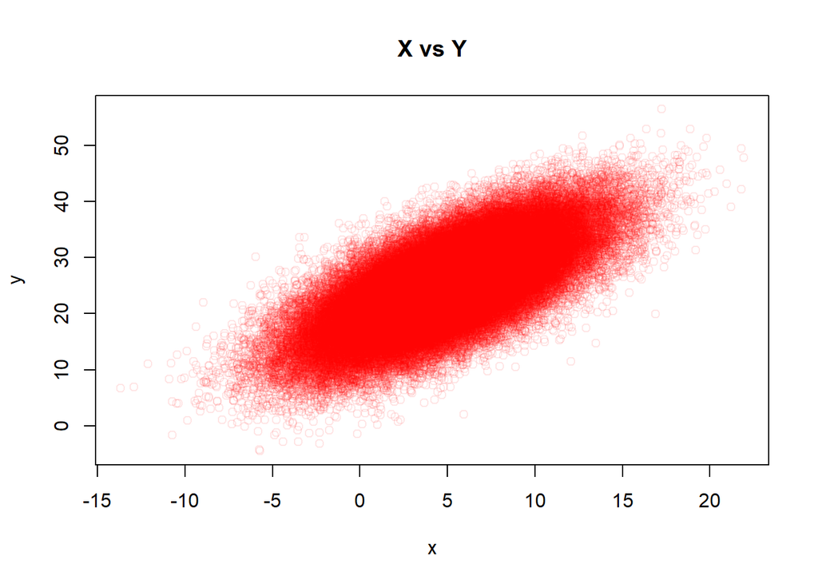

```
##            [,1]     [,2]
## [1,]  9.2021277 31.18761
## [2,] -3.4843003 10.90579
## [3,]  9.0362825 27.60380
## [4,] -0.7046792 26.31094
## [5,]  5.6598513 30.41595
## [6,]  0.3407895 20.82524
```

```r
library(magrittr)
library(MASS)
set.seed(689)
# produce sample
df  = mvrnorm(100000,mu=c(5,25),Sigma = matrix(c(16,19.6,19.6,49),2,2))
df  %T>% plot(.,col=rgb(1, 0, 0, 0.1),main="X vs Y",xlab="x",ylab="y") %>% head()
```

Use these function to get samples and calculate $\bar{y}$

```r
srs = function(n,N,object){
    object[sample(N,n)] %>% mean()
}

ratio.est = function(n,N,object,ratio){
  select = sample(N,n)
  sum(object[select])/sum(ratio[select])*mean(ratio)
}


#ybar
c(srs(100,100000,df[,2]),ratio.est(100,100000,df[,2],df[,1]))
```

```
## [1] 24.96711 25.32930
```

mse is calculate by

```r
mse.compare.plot = function(rho,sample.n,pop.n,exp.n,data,plot=TRUE){
  mu.y = data[,2] %>% mean()
  ybar.srs = replicate(exp.n,srs(sample.n,pop.n,data[,2]))
  ybar.ratio = replicate(exp.n,ratio.est(sample.n,pop.n,data[,2],data[,1]))
  if(plot){
    #plot
    par(mfrow=c(1,2))
    ybar.srs %>% density() %>% plot(.,main=paste("rho=",rho,",ybar estimate"),lwd=2)
    abline(v=mu.y,col="red")
    ybar.ratio %>% density() %>% plot(.,main="ratio estimator estimate",lwd=2)
    abline(v=mu.y,col="red")
    par(mfrow=c(1,1))
  }
  #mse
  mse.srs = ybar.srs %>% '-'(mu.y) %>% .^2 %>% mean()
  mse.ratio = ybar.ratio %>% '-'(mu.y) %>% .^2 %>% mean()

  #res
  res = c(mse.srs,mse.ratio)
  names(res) =c("ybar","ratio estimator")
  return(res)
}
```

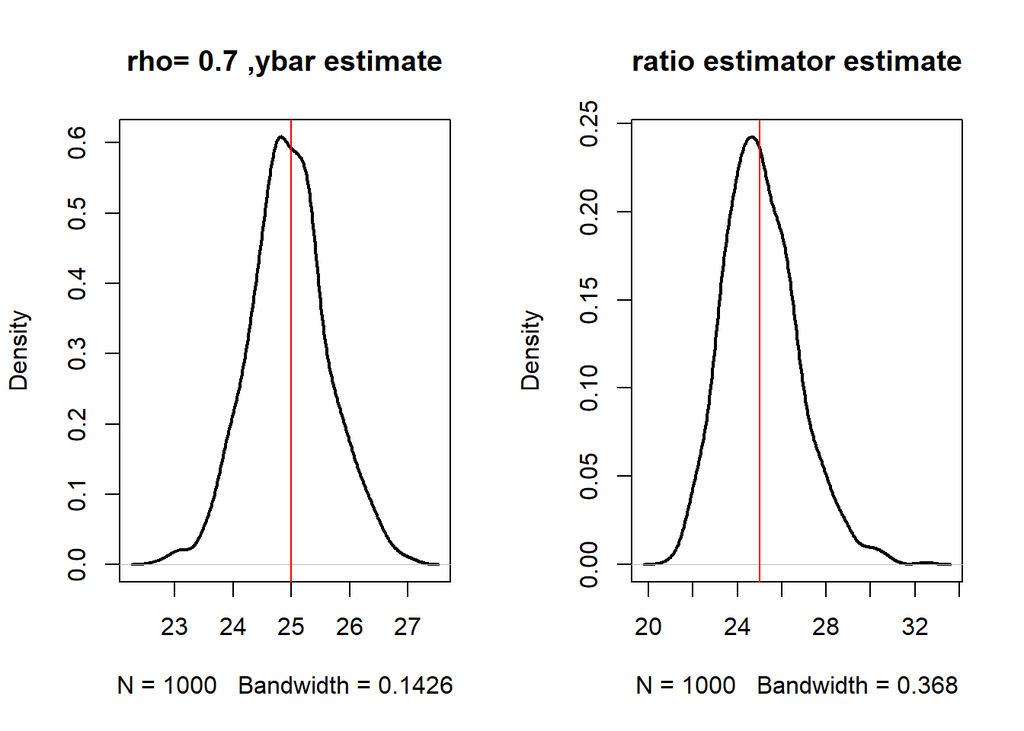

```
##            ybar ratio estimator
##       0.4700056       2.8430787
```

```r
mse.compare.plot(0.7,100,100000,1000,df,T)
```

###

Now, we want to compare mse in different $\rho$, first set mu(x,y)=(15,15) and var(x,y)=c(49,49),then $\bar{y_r}$ should be better when
$$\rho > \frac{1}{2}\frac{15}{15}\frac{49}{49}=\frac{1}{2}$$

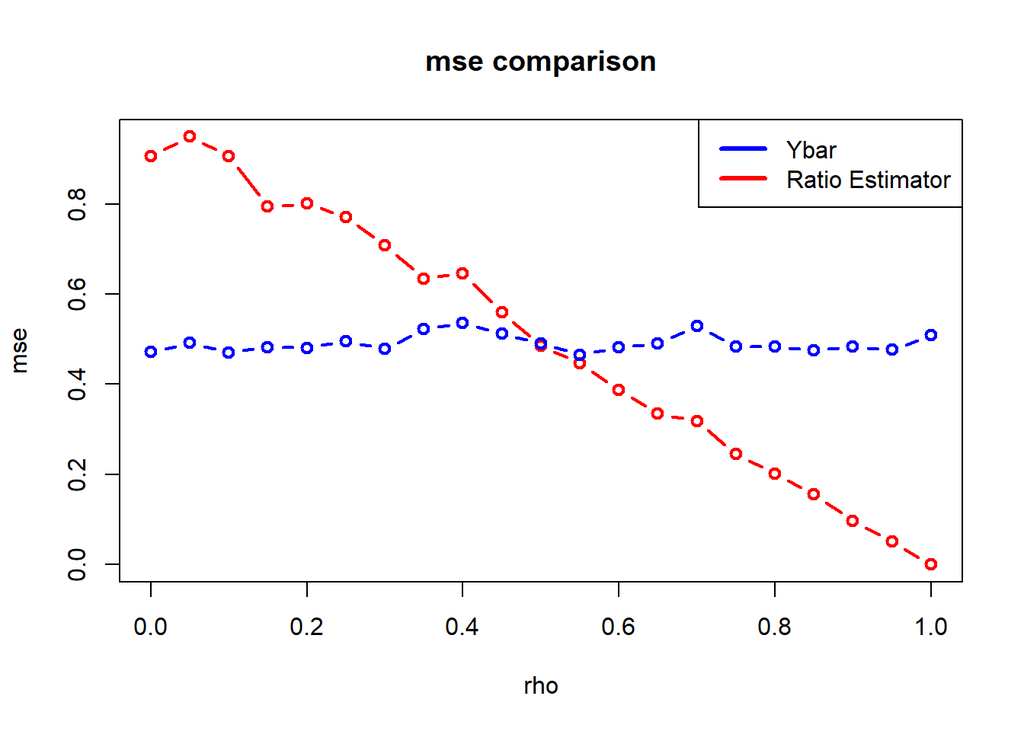

```r
rho.compare = function(rho, pop.n, sample.n, exp.n,plot=F){
  df = mvrnorm(pop.n,mu=c(15,15),Sigma = matrix(c(49,49*rho,49*rho,49),2,2))
  res = c(rho,mse.compare.plot(rho,sample.n,pop.n,exp.n,df,plot))
  names(res)[1]="rho"
  return(res)
}

temp = sapply(seq(0,1,by=0.05),rho.compare,pop.n=100000,sample.n=100,exp.n=1000)

plot(main="mse comparison",temp[1,],temp[3,],type="b",lwd=2,col="red",xlab="rho",ylab="mse")
lines(temp[1,],temp[2,],type="b",lwd=2,col="blue")
legend("topright",c("Ybar","Ratio Estimator"),col=c("blue","red"),lwd="3")
```

Next, we set mu = c(15,10), var= c(49,49),then $\bar{y_r}$ should be better when
$$\rho > \frac{1}{2}\frac{10}{15}\frac{49}{49}=\frac{1}{3}$$

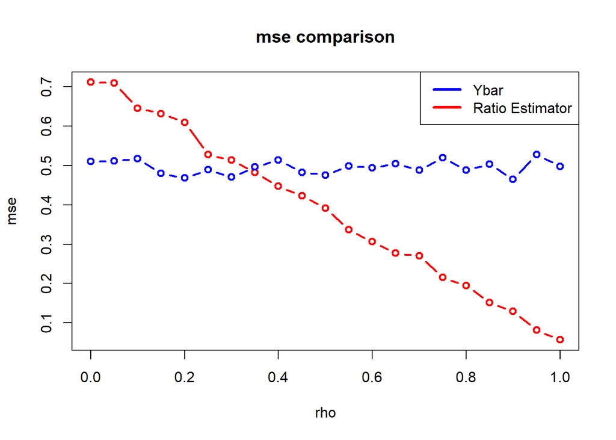

```r
rho.compare = function(rho, pop.n, sample.n, exp.n,plot=F){
  df = mvrnorm(pop.n,mu=c(15,10),Sigma = matrix(c(49,49*rho,49*rho,49),2,2))
  res = c(rho,mse.compare.plot(rho,sample.n,pop.n,exp.n,df,plot))
  names(res)[1]="rho"
  return(res)
}

temp = sapply(seq(0,1,by=0.05),rho.compare,pop.n=100000,sample.n=100,exp.n=1000)

plot(main="mse comparison",temp[1,],temp[3,],type="b",lwd=2,col="red",xlab="rho",ylab="mse")
lines(temp[1,],temp[2,],type="b",lwd=2,col="blue")
legend("topright",c("Ybar","Ratio Estimator"),col=c("blue","red"),lwd="3")
```

## Summary

ratio estimator should be a good estimator when

1. (x,y) are highly correlated
2. regression line of Y on X should go through (0,0)
3. $\bar{x}$ is big, $S_x$ is small.